# Por siempre mi persona favorita

Enrique Castañeda

04 diciembre, 2020 19:06:07

# PARA LILIANA

## El unico y verdadero amor de mi vida.

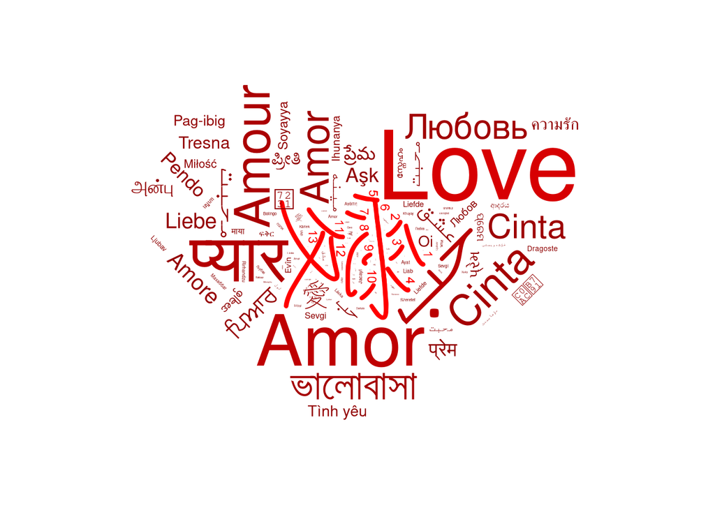

Se que a estas alturas las cosas no estan para nada bien entre nosotros; creo que lo nuestro esta muy muy lejos de ser considerado perfecto pero tambien comprendo y entiendo todo cuanto nos a costado llegar hasta donde estamos ahora. Se que esto sonara mas como un intento tonto y sin sentido ni fin; como un ultimo intento inutil por causar una ultima buena impresion.

Más todo cuanto tengo y poseo lo imprimo en esta infima demostracion de respeto cariño y amor que mas que una disculpa es una suplica un pequeño discurso una pequeña demostracion de lo mucho que significas para mi y de cuan importante eres en mi vida y aunque talvez ya nada de lo que diga o haga importe de todas formas invierto mi tiempo y esfuerzo en esta talvez futil causa.

## Primeros Momentos

Las primeras veces que quedamos en salir juntos me pareciste una persona peculiar y muy bondadosa me encanto conversar contigo y descubriri muchas cosas sobre ti y tu vida; aunque me la pasaba a veces parloteando como un loro, me agradaba saber que no eras solo un cascaron bonito si no que tambien disponias de una gran y atrayente personalidad que me cautivo desde el inicio y que poco a poco me encandilaba y me hacia querer saber mas de ti y contarte aun mas cosas de mi.